# ChipSeq peak sequence extraction

This document details working extraction of ChIPseq peak sequences for use with FIMO.

## Setting up the environment

These are packages you will need for this notebook. For exact versions used, please refer to the session info at the bottom of this notebook.

```r
##########################################################################################
library('tidyverse')
library('GenomicRanges')
library('BSgenome.Hsapiens.UCSC.hg38')
```

I want to set a base directory that we can use as a link to the directory where we will do most of the work. I use two directories here because the Workspace is what is pushed to GitHub and contains scripts and plot files, but the Repository is where more of the big data is stored that does not get pushed.

```r
##########################################################################################
generalDatasets = 'C:/Users/chughes/Documents/bccrc/projectsRepository/generalDatasets'
baseWorkspace = 'C:/Users/chughes/Documents/bccrc/projectsWorkspace/sorensenLab/relatedToDlg2'
baseRepository = 'C:/Users/chughes/Documents/bccrc/projectsRepository/sorensenLab/relatedToDlg2'
#generalDatasets = 'C:/Users/chris/OneDrive/Documents/bccrc/projectsRepository/generalDatasets'
#baseWorkspace = 'C:/Users/chris/OneDrive/Documents/bccrc/projectsWorkspace/sorensenLab/relatedToYbx1'
#baseRepository = 'C:/Users/chris/OneDrive/Documents/bccrc/projectsRepository/sorensenLab/relatedToYbx1'
```

## Data processing

First get the gtf file we used for alignment and will use for annotation below.

```r
##########################################################################################
#totalGtf = as.data.frame(rtracklayer::import.gff('C:/Users/chughes/Documents/bccrc/databases/hg38/gencode_gtf/hg38.gtf.gz'))
totalGtf = as.data.frame(rtracklayer::import.gff('D:/databases/projectEwsDlg2/baseGenomeFiles/genome.gtf'))
```

Add counts for GGAA and TTCC within the peaks, as the enrichment score isn’t entirely reliable.

```r
##########################################################################################
macsPeaks = read_tsv(paste(baseRepository, '/sequencing20210114_a673ChipSeqReprocessingAynaud/SRR8832674_peaks.xls', sep = ''),
                     skip = 30,
                     col_names = c('chr','start','end','length','abs_summit','pileup','logPValue','fold_enrichment','logQValue','name'))
peaksGr = makeGRangesFromDataFrame(macsPeaks)
peakSequences = getSeq(Hsapiens, peaksGr)
names(peakSequences) = macsPeaks$name
macsPeaks$ggaaCounts = vcountPattern('GGAAGGAAGGAAGGAA', peakSequences) + vcountPattern('TTCCTTCCTTCCTTCC', peakSequences)
saveRDS(macsPeaks, paste(baseRepository, '/sequencing20210114_a673ChipSeqReprocessingAynaud/SRR8832674_peaksGgaaAnnotated.rds', sep = ''))
```

Now we can extract our peaks of interest from the data, all those that fall within DLG2 (+100Kb from the TSS).

```r
##########################################################################################
#the transcript with the closest 'exon' is ENST00000426717.6
dlg2Gtf = totalGtf %>%
  filter(grepl('DLG2$', gene_name)) %>%
  filter(grepl('gene', type)) %>%
  mutate(end = end + 100000) #we add 100kb here to search beyond the annotated TSS
##
macsPeaks = read_tsv(paste(baseRepository, '/sequencing20210114_a673ChipSeqReprocessingAynaud/SRR8832674_peaks.xls', sep = ''),
                     skip = 30,
                     col_names = c('chr','start','end','length','abs_summit','pileup','logPValue','fold_enrichment','logQValue','name')) %>%
  filter(grepl('chr11', chr)) %>%
  filter(start > dlg2Gtf$start & end < dlg2Gtf$end) %>%
  mutate(midPoint = start + round(length / 2, 0)) %>%
  filter(fold_enrichment >= 10)
##
```

Now get the sequences. For this we use BSGenome and getseq.

```r
##########################################################################################
##expand the peaks on both sides
macsPeaksExpanded = macsPeaks %>%
  mutate(start = start - 20) %>%
  mutate(end = end + 20)
##
peaksGr = makeGRangesFromDataFrame(macsPeaksExpanded)
strand(peaksGr)[] = '-'
##
peakSequences = getSeq(Hsapiens, peaksGr)
names(peakSequences) = macsPeaks$name
##
writeXStringSet(peakSequences,
                file = paste(baseRepository, '/sequencing20210114_a673ChipSeqReprocessingAynaud/fimo/SRR8832674_peakSequences.fasta', sep = ''))
```

Count the number of GGAA mSats in each.

```r
##########################################################################################
macsPeaksExpanded$mSats = vcountPattern('GGAAGGAAGGAAGGAA', peakSequences)
```

Read the FIMO results and add the p-values.

```r
##########################################################################################
ma0149 = read_tsv(paste(baseRepository, '/sequencing20210114_a673ChipSeqReprocessingAynaud/fimo/fimo_MA0149.1/fimo.txt', sep = '')) %>%
  dplyr::select(sequence_name, `p-value`) %>%
  group_by(sequence_name) %>%
  summarise(across(where(is.double), list(min = min))) %>%
  dplyr::rename('name' = sequence_name, 'ma0149pVal' = `p-value_min`)
#p < 0.0005 was cutoff in the manuscript

ma0475 = read_tsv(paste(baseRepository, '/sequencing20210114_a673ChipSeqReprocessingAynaud/fimo/fimo_MA0475.1/fimo.txt', sep = '')) %>%
  dplyr::select(sequence_name, `p-value`) %>%
  group_by(sequence_name) %>%
  summarise(across(where(is.double), list(min = min))) %>%
  dplyr::rename('name' = sequence_name, 'ma0475pVal' = `p-value_min`)
#p < 0.1 was the cutoff in the manuscript

##
motifPeaks = macsPeaksExpanded %>%
  left_join(ma0149) %>%
  left_join(ma0475) %>%
  mutate(peak = factor(seq(5,1,-1), levels = seq(1,5,1)))
```

Make a plot of the calculated values.

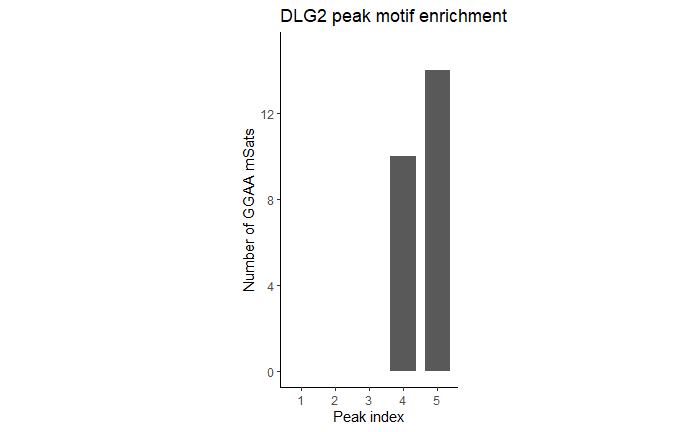

```r
##########################################################################################
ggplot(motifPeaks, aes(peak, mSats)) +
  geom_col(width = 0.75) +
  labs(x = 'Peak index', y = 'Number of GGAA mSats', title = 'DLG2 peak motif enrichment') +
  scale_y_continuous(limits = c(0,15), breaks = seq(0,20,4)) +
  theme_classic() +
  theme(aspect.ratio = 2/1)
ggsave(paste(baseRepository, '/sequencing20210114_a673ChipSeqReprocessingAynaud/fimo/barplot_dlg2ChipSeqPeakMotifEnrichment.pdf', sep = ''),
       height = 2, width = 2, useDingbats = FALSE)
```

[session information not shown]